# Decision Trees for Political Science

Ted Ellsworth

3/4/2019

# 1.1 Statistical Learning in R

To start off we will be using replication data from Rottman, Farriss, and Poe 2009 (Interational Migration Review 43(1))

The first step is to divide the data into training and test data. For ease of analysis we will do a zero-imputation for all missing values. There are two caveats I would highlight:

1. This is for ease; this is likely not the appropriate response for the data.
2. Should any other imputation method be used, you *must* split the data into train/test data *prior* to imputation.

```r
set.seed(999)
load("USmigration.RData")
x <- x[,-c(1:3,5)]
x <- x %>%
  mutate_at(vars(1:15), funs(replace(., is.na(.), 0)))

train <- sample(1:nrow(x), 0.8*nrow(x))
imm.train <- x[train,]
imm.test <- x[-train,]
```

# 1.2 OLS

Let’s start with a linear regression model. As a starting point we will rely on the package `caret` to train and test our data. The `caret` package is designed as a core R package for machine learning and has numerous extentions. For more information you can check out their [webpage](http://topepo.github.io/caret/index.html).

```r
imm.lm <- train(grant_officer~., #a.fit the model
                data = imm.train,
                method = "lm",
                metric = "RMSE",
                na.action = na.omit)
summary(imm.lm)
```

```
##
## Call:
## lm(formula = .outcome ~ ., data = dat)
##
## Residuals:
##     Min      1Q  Median      3Q     Max
## -47.830  -9.615  -1.999   6.868  97.727
##
## Coefficients:
##                 Estimate Std. Error t value Pr(>|t|)
## (Intercept)    16.518756   5.104418   3.236 0.001260 **
## pts_state_lag   1.783176   0.748197   2.383 0.017386 *
## polity2_lag    -0.681269   0.138583  -4.916 1.07e-06 ***
## mlagdummy      -6.374543   1.529290  -4.168 3.40e-05 ***
## log_trade2004  -0.179238   0.240345  -0.746 0.456031
## sanctions       0.665139   2.358605   0.282 0.778011
## english98      -3.871513   1.602959  -2.415 0.015944 *
## arabic98        3.676772   2.190890   1.678 0.093689 .
## spanish98       1.060864   2.332552   0.455 0.649368
## top10undoc    -11.301727   3.288692  -3.437 0.000619 ***
## post2001       -8.511857   1.321682  -6.440 2.04e-10 ***
## panel_officer   5.671325   0.445125  12.741  < 2e-16 ***
## panel_judge    -0.121552   0.599449  -0.203 0.839363
## casfiled        0.004727   0.001627   2.906 0.003759 **
## hreciev        -0.004587   0.001227  -3.738 0.000199 ***
## ---
## Signif. codes:  0 '***' 0.001 '**' 0.01 '*' 0.05 '.' 0.1 ' ' 1
##
## Residual standard error: 18.82 on 816 degrees of freedom
## Multiple R-squared:  0.5078, Adjusted R-squared:  0.4994
## F-statistic: 60.14 on 14 and 816 DF,  p-value: < 2.2e-16
```

```r
imm.lm.pred <- predict(imm.lm, imm.test) #b. calculate predictions
```

# 1.3 CART: Recursive Partitioning

Now we will grow our first tree. It is generally advisable to grow a large tree and then prune back. This is done using the rpart.control function which contains the hyperparameters of our decision tree.

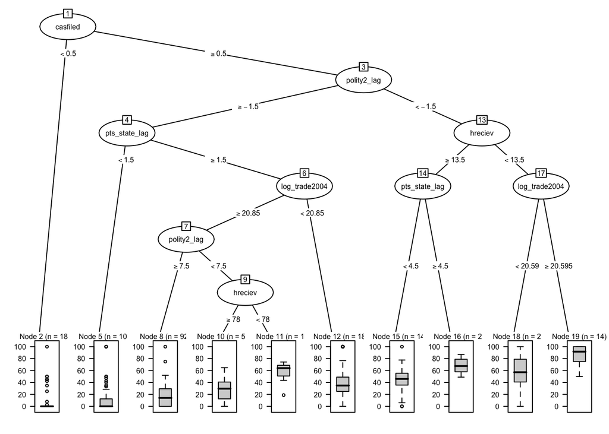

```r
tree1 <- rpart(grant_officer~. -panel_officer -panel_judge,
               data = imm.train,
               control = rpart.control(minsplit = 20, #controls the number of splits
                                       minbucket = 10, # number of observations at terminal nodes
                                       cp = 0.01, #complexity parameter, small cp means large tree
                                       maxdepth = 20), #depth from origin to terminal node
               method = "anova")
tree1.pr <- as.party(tree1)
plot(tree1.pr, gp = gpar(fontsize = 6))
```

```r
print(tree1)
```

```
## n= 831
##
## node), split, n, deviance, yval
##       * denotes terminal node
##
##   1) root 831 586953.100 27.238060
##     2) casfiled< 0.5 181  21868.500  2.227249 *
##     3) casfiled>=0.5 650 420333.500 34.202610
##       6) polity2_lag>=-1.5 443 241236.900 26.501890
##        12) pts_state_lag< 1.5 102  41626.750  9.769684 *
##        13) pts_state_lag>=1.5 341 162511.700 31.506830
##          26) log_trade2004>=20.85 158  66407.180 24.365330
##            52) polity2_lag>=7.5 92  31991.800 18.044510 *
##            53) polity2_lag< 7.5 66  25616.090 33.176160
##             106) hreciev>=78 55  14845.270 28.242230 *
##             107) hreciev< 78 11   2737.389 57.845850 *
##          27) log_trade2004< 20.85 183  81089.070 37.672710 *
##       7) polity2_lag< -1.5 207  96604.980 50.682900
##        14) hreciev>=13.5 168  50006.700 47.192760
##          28) pts_state_lag< 4.5 148  37722.560 44.430210 *
##          29) pts_state_lag>=4.5 20   2796.398 67.635660 *
##        15) hreciev< 13.5 39  35736.520 65.717340
##          30) log_trade2004< 20.595 25  23624.680 55.319060 *
##          31) log_trade2004>=20.595 14   4581.745 84.285710 *
```

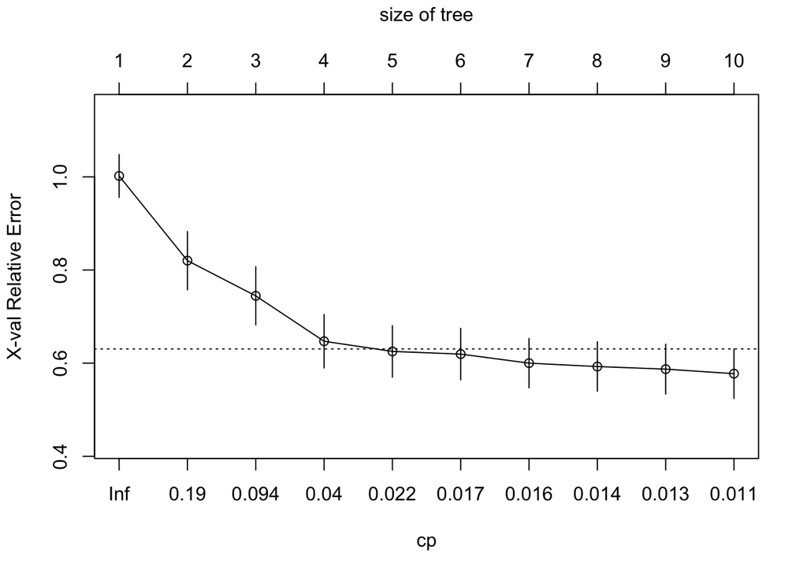

```r
plotcp(tree1) #error ~ number of features, we are interested in the sub tree which preserves the reduction in error without introducing more noise to the result.
```

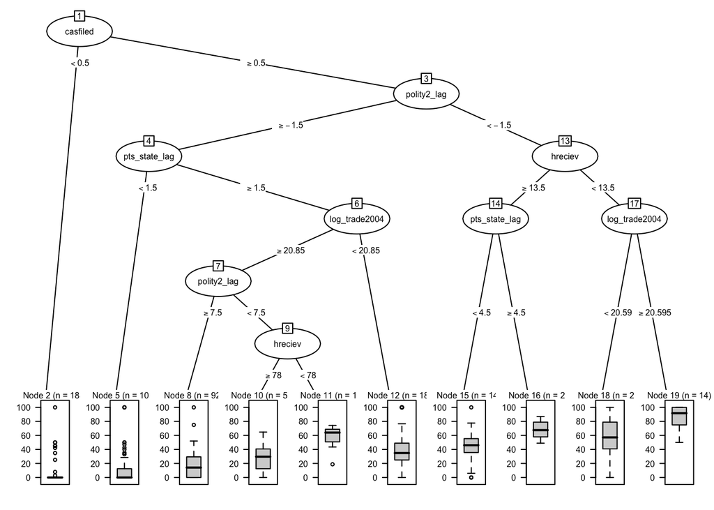

```r
minx <- which.min(tree1$cptable[,'xerror']) #minimum error
mincp <- tree1$cptable[minx, "CP"]
tree1.split <- prune(tree1, mincp)
tree1.pr.min <- as.party(tree1.split)
plot(tree1.pr.min, gp = gpar(fontsize = 6))
```

```r
minx <- which.min(tree1$cptable[,"xerror"]) #cp 1sd from minumum error
minxse <- tree1$cptable[minx,"xerror"] + tree1$cptable[minx,"xstd"]
minse <- which(tree1$cptable[1:minx,"xerror"] < minxse)
mincp2 <- tree1$cptable[minse[1],"CP"]
tree1.split.1se <- prune(tree1, mincp2)
print(tree1.split.1se) #Let's look at node impurity
```

```
## n= 831
##
## node), split, n, deviance, yval
##       * denotes terminal node
##
##  1) root 831 586953.10 27.238060
##    2) casfiled< 0.5 181  21868.50  2.227249 *
##    3) casfiled>=0.5 650 420333.50 34.202610
##      6) polity2_lag>=-1.5 443 241236.90 26.501890
##       12) pts_state_lag< 1.5 102  41626.75  9.769684 *
##       13) pts_state_lag>=1.5 341 162511.70 31.506830
##         26) log_trade2004>=20.85 158  66407.18 24.365330 *
##         27) log_trade2004< 20.85 183  81089.07 37.672710 *
##      7) polity2_lag< -1.5 207  96604.98 50.682900 *
```

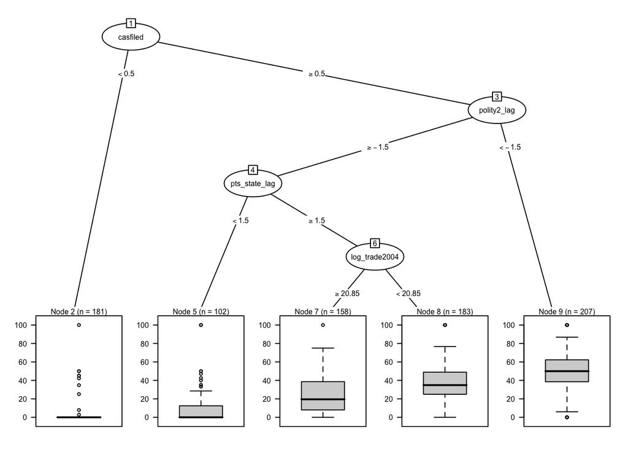

```r
tree1.pr.1se <- as.party(tree1.split.1se)
plot(tree1.pr.1se, gp = gpar(fontsize = 6))
```

```r
tree1.pred <- predict(tree1.split.1se, imm.test)
```

# 1.4 Bootstrap Aggregating(Bagging)

```r
#Bootstrap Aggregating (Bagging)
require(foreach) #Special loop operator.
tree2.bag <- foreach(m = 1:100, .combine = cbind) %do% {
  rows <- sample(nrow(imm.train), replace = T) #we are using new samples of the training data and replacing them. Our final output is going to be an aggregate of the sample training errors.
  cart <- rpart(grant_officer~.,
                 data = imm.train,
                 control = rpart.control(minsplit = 20,
                                         minbucket = 10,
                                         cp = 0.01,
                                         maxdepth = 20),
                 method = "anova")
  preds <- predict(cart, imm.test)
}
```

# 1.5 The Random Forest

Before running our random forest model it is necessary to specify the tuning parameters.

There are three parameters of interest:

M is the predictor subset of P (mtry in caret). This is the most important parameter. A good rule of thumb is use a number m = sqrt(p) for classification problems and m = p/3 for regression. In this instance, we will derive our final estimate from bootstrapped samples where m = 2, 5, 10.

Second, note that the larger the number of trees, the more smooth the prediction boundary. In practice you should rarely dip below 100 trees per forest.

I will also set the values for importance and proximity to true so that we can assess the relationships between parameters and feature importance.

```r
control = trainControl(method = "cv",
                       number = 10)
rfgrid = expand.grid(mtry = c(2,5,10)) #Number of Trees with a grid for hyperperameter tuning.
rf.imm <- train(grant_officer~.,
                 data = imm.train,
            metric = "RMSE",
            method = "rf",
            trControl = control,
            trGrid = rfgrid,
            n.trees = 500,
            na.action = na.omit,
            importance = T,
            proximity = T)
rfpred <- predict(rf.imm, imm.test)
```

# 1.6 Evaluating Out of Sample Performance

we will use the postResample command from caret to assess model performance. The post resample takes your predictions and tests their deviance from observed values across a number of samples.

```r
postResample(imm.lm.pred, imm.test$grant_officer) #OLS
```

```
##       RMSE   Rsquared        MAE
## 20.3099769  0.4630074 13.2919559
```

```r
postResample(tree1.pred, imm.test$grant_officer) #CART
```

```
##       RMSE   Rsquared        MAE
## 22.5959004  0.3417867 15.3148217
```

```r
postResample(rowMeans(tree2.bag), imm.test$grant_officer) #BAGGING
```

```
##       RMSE   Rsquared        MAE
## 21.9718697  0.3922832 13.5216737
```

```r
postResample(rfpred, imm.test$grant_officer) #RF
```

```
##       RMSE   Rsquared        MAE
## 20.9325642  0.4352102 12.3175111
```

Note here that our OLS model offeres the smallest RMSE. This is not surprising, given that trees tend to reduce bias in the training data while increasing variance across outcomes. In absolute terms, the random forest has the smallest error among the models, suggesting that OLS may be ariving at low error by chance.

# 2 The Classification Setting

Let’s turn to a more familiar example in Fearon and Laitin (2003).

# 2.1 Preprocessing

Here we are going to use `createDataPartition()` from `caret` in order to sample within the levels of the new outcome variable `peace` when splitting the data. Because a majority of features in Fearon and Laitin’s model are factoral, we will use median imputation to deal with missing data.

```r
require(foreign)
cwar <- read.dta("repdata.dta")
cwar <- cwar[,-c(2,3,4,6,13,16,25)]
cwar <- subset(cwar, onset <= 1)
cwar$peace <- factor(
  cwar$onset,
  levels=c(0,1),
  labels=c("peace", "war"))
#Training Partition
inTrain <- createDataPartition(cwar$peace,
                               p = 0.8,
                               list = F,
                               times = 1)
#Split Training Data and Testing Data
war.train <- cwar[inTrain,]
war.train <- data.frame(lapply(war.train,function(x) { #this is a median imputation, note that you *must* split the data before imputing missings.
    if(is.numeric(x)) ifelse(is.na(x),median(x,na.rm=T),x) else x}))

war.test <- cwar[-inTrain,]
war.test <- data.frame(lapply(war.test,function(x) {
    if(is.numeric(x)) ifelse(is.na(x),median(x,na.rm=T),x) else x}))
```

# 2.2 Cross Validation

```r
control = trainControl(method = "cv", #This is a standard cross-validation meaning that we are collecting an average of sample performances over 10 folds in the data. there are alternative algorithms such as LOOCV and repeated CV which resample based on the columns of the data frame.
                       number = 10,
                       summaryFunction = twoClassSummary, #The summary function and classProbs argument are for classification problems. The first allows you to assess the probability across two classes (think precision vs. recall).
                       classProbs = T,
                       sampling = "smote") #stands for Synthetic Minority Over-Sampling technique. Becuase Fearon and Laitin's DV has a rare event (civil war) we have class imbalance. SMOTE algorithms tend to work better than downsampling because they balance on the class density rather than simply sampling on the overrepresented class.
```

# 2.3 Logistic Regression

```r
glm <- train(as.factor(peace) ~ warl + gdpenl + lpopl1 + lmtnest + ncontig + Oil + nwstate + instab + ethfrac + relfrac,
             data = war.train,
             trControl = control,
             method = "glm", #default logit
             metric = "ROC") #Classification metric
print(glm)
```

```
## Generalized Linear Model
##
## 5288 samples
##   10 predictor
##    2 classes: 'peace', 'war'
##
## No pre-processing
## Resampling: Cross-Validated (10 fold)
## Summary of sample sizes: 4759, 4759, 4759, 4760, 4759, 4760, ...
## Addtional sampling using SMOTE
##
## Resampling results:
##
##   ROC      Sens       Spec
##   0.71957  0.7844231  0.5319444
```

```r
pred.glm <- predict(glm, war.test)
confusionMatrix(pred.glm, war.test$peace, positive = "war")
```

```
## Confusion Matrix and Statistics
##
##           Reference
## Prediction peace  war
##      peace  1009   11
##      war     290   11
##
##                Accuracy : 0.7721
##                  95% CI : (0.7486, 0.7945)
##     No Information Rate : 0.9833
##     P-Value [Acc > NIR] : 1
##
##                   Kappa : 0.0383
##  Mcnemar's Test P-Value : <2e-16
##
##             Sensitivity : 0.500000
##             Specificity : 0.776751
##          Pos Pred Value : 0.036545
##          Neg Pred Value : 0.989216
##              Prevalence : 0.016654
##          Detection Rate : 0.008327
##    Detection Prevalence : 0.227858
##       Balanced Accuracy : 0.638376
##
##        'Positive' Class : war
##
```

# 2.4 CART W/0 Bagging

```r
tree.war <- train(as.factor(peace) ~ warl + gdpenl + lpopl1 + lmtnest + ncontig + Oil + nwstate + instab + ethfrac + relfrac,
             data = war.train,
             trControl = control,
             method = "rpart",
             metric = "ROC")

pred.rp <- predict(tree.war, war.test)
confusionMatrix(pred.rp, war.test$peace, positive = "war")
```

```
## Confusion Matrix and Statistics
##
##           Reference
## Prediction peace war
##      peace   938  15
##      war     361   7
##
##                Accuracy : 0.7154
##                  95% CI : (0.6902, 0.7396)
##     No Information Rate : 0.9833
##     P-Value [Acc > NIR] : 1
##
##                   Kappa : 0.0046
##  Mcnemar's Test P-Value : <2e-16
##
##             Sensitivity : 0.318182
##             Specificity : 0.722094
##          Pos Pred Value : 0.019022
##          Neg Pred Value : 0.984260
##              Prevalence : 0.016654
##          Detection Rate : 0.005299
##    Detection Prevalence : 0.278577
##       Balanced Accuracy : 0.520138
##
##        'Positive' Class : war
##
```

# 2.5 Tree W/Bagging

```r
tree.bag.war <- train(as.factor(peace) ~ warl + gdpenl + lpopl1 + lmtnest + ncontig + Oil + nwstate + instab + ethfrac + relfrac,
             data = war.train,
             trControl = control,
             method = "treebag", #alternative syntax for the foreach loop, remember to be careful about hyperperameters.
             metric = "ROC")

pred.rp.bag <- predict(tree.bag.war, war.test)
confusionMatrix(pred.rp.bag, war.test$peace, positive = "war")
```

```
## Confusion Matrix and Statistics
##
##           Reference
## Prediction peace  war
##      peace  1007   13
##      war     292    9
##
##                Accuracy : 0.7691
##                  95% CI : (0.7454, 0.7916)
##     No Information Rate : 0.9833
##     P-Value [Acc > NIR] : 1
##
##                   Kappa : 0.0255
##  Mcnemar's Test P-Value : <2e-16
##
##             Sensitivity : 0.409091
##             Specificity : 0.775212
##          Pos Pred Value : 0.029900
##          Neg Pred Value : 0.987255
##              Prevalence : 0.016654
##          Detection Rate : 0.006813
##    Detection Prevalence : 0.227858
##       Balanced Accuracy : 0.592151
##
##        'Positive' Class : war
##
```

# 2.6 Random Forest

```r
rf.war <- train(as.factor(peace) ~ warl + gdpenl + lpopl1 + lmtnest + ncontig + Oil + nwstate + instab + ethfrac + relfrac,
             data = war.train,
             trControl = control,
            method = "rf",
            n.trees = 500,
            metric = "ROC",
            importance = T, #This output will enable us to explore which variables were important in the prediction model
            proximity  = T) #Flip to yes to obtain variable dependencies, useful for interaction detection.

rf.pred.w <- predict(rf.war, newdata = war.test)
confusionMatrix(rf.pred.w, war.test$peace, positive = "war")
```

```
## Confusion Matrix and Statistics
##
##           Reference
## Prediction peace  war
##      peace  1105   17
##      war     194    5
##
##                Accuracy : 0.8403
##                  95% CI : (0.8194, 0.8596)
##     No Information Rate : 0.9833
##     P-Value [Acc > NIR] : 1
##
##                   Kappa : 0.0157
##  Mcnemar's Test P-Value : <2e-16
##
##             Sensitivity : 0.227273
##             Specificity : 0.850654
##          Pos Pred Value : 0.025126
##          Neg Pred Value : 0.984848
##              Prevalence : 0.016654
##          Detection Rate : 0.003785
##    Detection Prevalence : 0.150643
##       Balanced Accuracy : 0.538964
##
##        'Positive' Class : war
##
```

# 2.7 Out of Sample Performance ROC

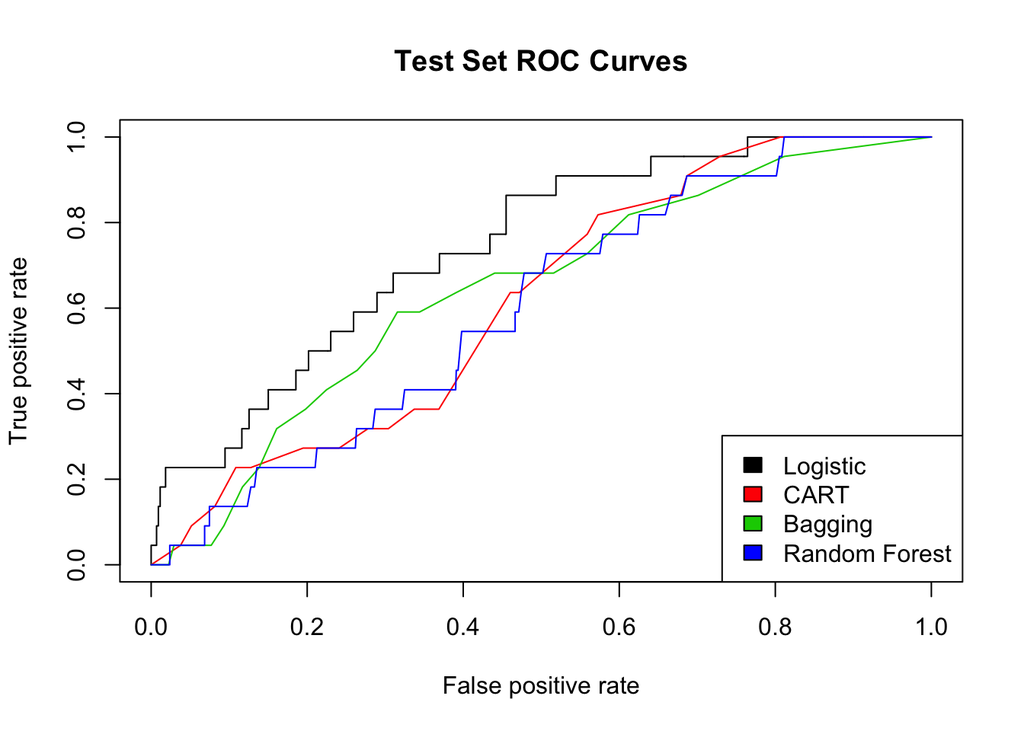

```r
set.seed(999)
#Previously we looked at confusion matrices to evaluate our error, but we can also look at class probabilities by setting the `type` argument to "prob".
pred.glm.p <- predict(glm, war.test, type = "prob")[,2]
pred.rp.p <- predict(tree.war, war.test, type = "prob")[,2]
pred.rp.bag.p <- predict(tree.bag.war, war.test, type = "prob")[,2]
rf.pred.p <- predict(rf.war, newdata = war.test, type = "prob")[,2]
pred.list <- list(pred.glm.p, pred.rp.p, pred.rp.bag.p, rf.pred.p)
m <- length(pred.list)
actual <- rep(list(war.test$peace), m)
full <- prediction(pred.list, actual) #resample
full.pro <- performance(full, "tpr", "fpr") #estimate performance for true and false positive rate (sensitivity and specificity)
plot(full.pro, col = as.list(1:m), main = "Test Set ROC Curves")
legend(x = "bottomright",
       legend = c("Logistic", "CART", "Bagging", "Random Forest"),
       fill = 1:m)
```

A ROC curve is constructed by plotting the true positive rate (TPR) against the false positive rate (FPR). The true positive rate is the proportion of observations that were correctly predicted to be positive out of all positive observations (TP/(TP + FN)). Similarly, the false positive rate is the proportion of observations that are incorrectly predicted to be positive out of all negative observations (FP/(TN + FP))

The ROC curve shows the trade-off between sensitivity (or TPR) and specificity (1 – FPR). Classifiers that give curves closer to the top-left corner indicate a better performance.

We can immagine a solid line indicating no information from our tests. Note that the ROC does not depend on the class distribution. This makes it useful for evaluating classifiers predicting rare events

# 2.8 Inside the “Black Box”

# 2.8.1 Variable Importance

Below I provide just a few examples of how you can extract information from your non-parametric models for social science work. For more information I strongly reccommend checking out [this book](https://christophm.github.io/interpretable-ml-book/intro.html)

A full summary of each approach is offered in my accompanying presentation.

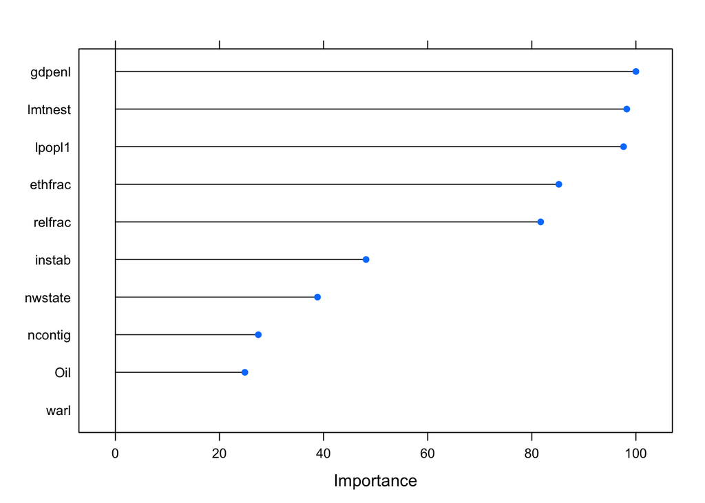

```r
plot(varImp(rf.war), top = 10)
```

# 2.8.2 Partial Dependence Plots

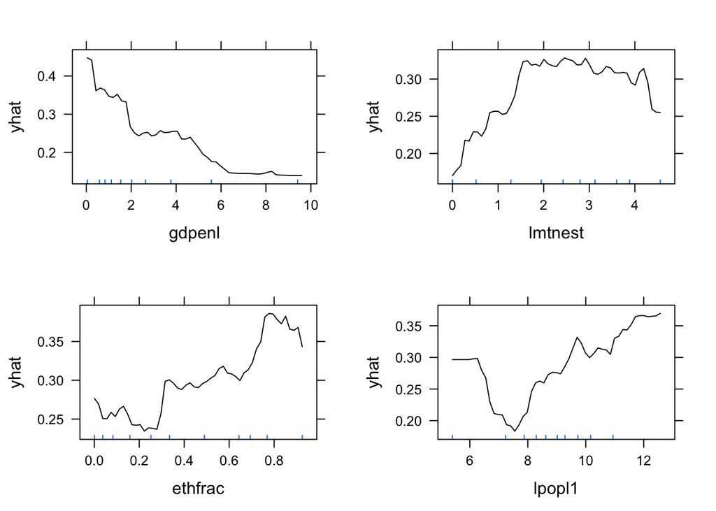

```r
#integrate marginal effect from observed values with partial function
pdp1 <- partial(rf.war, pred.var = "gdpenl", type = "classification", which.class = 2, prob = T, trim.outliers = T)
pdp2 <- partial(rf.war, pred.var = "lmtnest", type = "classification", which.class = 2, prob = T, trim.outliers = T)
pdp3 <- partial(rf.war, pred.var = "ethfrac", type = "classification", which.class = 2, prob = T, trim.outliers = T)
pdp4 <- partial(rf.war, pred.var = "lpopl1", type = "classification", which.class = 2, prob = T, trim.outliers = T)

#plot distribution of marginal effect across feature space
p1 <- plotPartial(pdp1, rug = T, train = war.train)
p2 <- plotPartial(pdp2, rug = T, train = war.train)
p3 <- plotPartial(pdp3, rug = T, train = war.train)
p4 <- plotPartial(pdp4, rug = T, train = war.train)
require(gridExtra)
grid.arrange(p1, p2, p3, p4, ncol = 2, nrow = 2)
```

#2.9 Local Inference (Individual Conditional Expectation Curve)

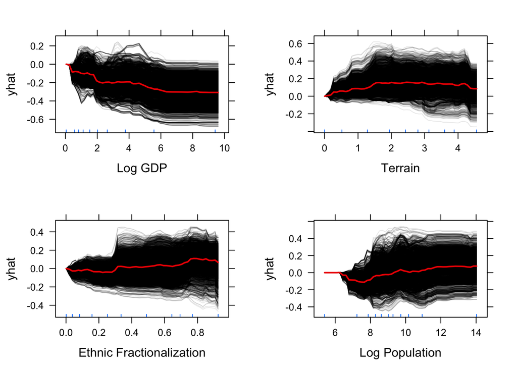

```r
#integrate marginal effect for each observation by simulating partial dependency for each observation. Then recenter the observations at the mean for the starting value of the feature space. [this may take a while]
ice1 <- rf.war %>%
  partial(pred.var = "gdpenl", ice = T, type = "classification", which.class = 2, prob = T,
          trim.outliers = T) %>%
  plotPartial(rug = T, train = war.train, alpha = 0.1, center = T, xlab = "Log GDP")
ice2 <- rf.war %>%
  partial(pred.var = "lmtnest", ice = T, type = "classification", which.class = 2, prob = T) %>%
  plotPartial(rug = T, train = war.train, alpha = 0.1, center = T, xlab = "Terrain")
ice3 <- rf.war %>%
  partial(pred.var = "ethfrac", ice = T, type = "classification", which.class = 2, prob = T,
          trim.outliers = T) %>%
  plotPartial(rug = T, train = war.train, alpha = 0.1, center = T, xlab = "Ethnic Fractionalization")
ice4 <- rf.war %>%
  partial(pred.var = "lpopl1", ice = T, type = "classification", which.class = 2, prob = T) %>%
  plotPartial(rug = T, train = war.train, alpha = 0.1, center = T, xlab = "Log Population")
grid.arrange(ice1,ice2,ice3,ice4)
```